# Week 3, Meeting 1

# (from last time) More data structures

## Tuples

A Tuple is an immutable sequence, this means:

- It cannot be modified once created, you can make a new one
- Its elements have a definite order.
- A tuple can be indexed and sliced using [index] notation.
- Like a list, it can have mixed types of data
- Iterable

## Tuples v Lists

A Tuple is a lot like a list, but:

- Tuples are immutable, Lists are mutable
- Tuples need slightly less memory
- Tuples iterate a little faster
- Tuples are useful for fixed data that should be unchanging (e.g., an ID number)

## Tuple operations

- Slice
- Max/Min
- Convert

Works like list slicing

```python
phy_sci = (2020, 3270, 2021, 3306, 2022, 3165, 2023, 3136, 2024, 3304)
print(f"{phy_sci[0]} Physical Science majors: {phy_sci[1]}") # Returns 2020 and 3270
print(phy_sci[0:4]) # Returns   2020, 3270, 2021, 3306
```

```
2020 Physical Science majors: 3270
(2020, 3270, 2021, 3306)
```

```python
phy_sci = (2020, 3270, 2021, 3306, 2022, 3165, 2023, 3136, 2024, 3304)
print(min(phy_sci[1::2]), max(phy_sci[1::2]))
```

```
3136 3306
```

```python
phy_sci = (2020, 3270, 2021, 3306, 2022, 3165, 2023, 3136, 2024, 3304)
phy_sci_list = list(phy_sci)
print(f"Is phy_sci_list a list? {isinstance(phy_sci_list, list)}")

phy_sci_tuple = tuple(phy_sci_list)
print(f"Is phy_sci_tuple a tuple? {isinstance(phy_sci_tuple, tuple)}")
```

```
Is phy_sci_list a list? True
Is phy_sci_tuple a tuple? True
```

## Example Tuple applications

- Constant
- Keys
- Hashable
- Swap
- Return Multiple values

```python
# https://identity.usc.edu/identity/color/#primarys
USC_Cardinal = ("#990000")
USC_Gold = ("#FFCC00")

# https://brand.ucla.edu/identity/colors
UCLA_COLORS = ("#2774AE", "#FFD100")  # This will never change

# See...
UCLA_COLORS[1] = USC_Gold # Throws an error
```

```
---------------------------------------------------------------------------
TypeError                                 Traceback (most recent call last)
Cell In[4], line 9
      6 UCLA_COLORS = ("#2774AE", "#FFD100")  # This will never change
      8 # See...
----> 9 UCLA_COLORS[1] = USC_Gold # Throws an error

TypeError: 'tuple' object does not support item assignment
```

- They can serve as dictionary keys (more on dictionaries later):

```python
enrollment_data = {
    ("Sep", 2024): 47335,
    ("Sep", 2023): 46678,
    ("Sep", 2022): 46430
}
print(enrollment_data)
```

```
{('Sep', 2024): 47335, ('Sep', 2023): 46678, ('Sep', 2022): 46430}
```

- Tuples are hashable and can be used in data structures that rely on hash tables for speed

```python
for key in enrollment_data:
    print(f"Key: {key}, Hash: {hash(key)}")
```

```
Key: ('Sep', 2024), Hash: 1974528681525958494
Key: ('Sep', 2023), Hash: -134754691591671803
Key: ('Sep', 2022), Hash: 4758319337381024563
```

You can easily swap two values using a tuple

```python
a, b = 5, 10
print(f"The original a, b is {a, b}")

a, b = b, a
print(f"The tuple swap is {a, b}")  # Output: 10, 5
```

```
The original a, b is (5, 10)
The tuple swap is (10, 5)
```

This is handy, in your functions, you can return multiple values using a tuple:

```python
def divide(a, b):
    quotient = a // b
    remainder = a % b
    return quotient, remainder  # Returns a tuple

x, y = divide(10, 3)
print(f"quotient: {x}, remainder: {y}")
```

```
quotient: 3, remainder: 1
```

## What are Sets?

- Sets are iterable but not sequences
- Sets are *unordered* and cannot be indexed
- Sets cannot have *duplicates*
- Sets are mutable
- Sets are used where order and duplicate values don’t matter https://docs.python.org/3/library/stdtypes.html#set

## Set applications

- in
- Intersection
- Difference
- uniqueness
- Membership testing is very fast

```python
import time

# Large list vs tuple
large_set = set(range(10**6))
large_list = list(range(10**6))
large_tuple = tuple(range(10**6))


# Measure list iteration time
start = time.time()
999999 in large_list
end = time.time()
print(f"List iteration took: {end - start:.6f} seconds")

# Measure tuple iteration time
start = time.time()
999999 in large_tuple
end = time.time()
print(f"Tuple iteration took: {end - start:.6f} seconds")

# Measure set iteration time
start = time.time()
999999 in large_set
end = time.time()
print(f"Set iteration took: {end - start:.6f} seconds")
```

```
List iteration took: 0.007335 seconds
Tuple iteration took: 0.006089 seconds
Set iteration took: 0.000021 seconds
```

- Finding the intersection of two sets is fast

```python
import time

large_set_A = set([range(10**6), -6])
large_set_B = set([range(10**6+1,10**6+10**6+1), -6])

start = time.time()
set_numbers = large_set_A & large_set_B
end = time.time()
print(f"Set intersection took: {end - start:.6f} seconds")

print(set_numbers)  # Output: {-6}
```

```
Set intersection took: 0.000015 seconds
{-6}
```

- Finding the difference of two sets
- Something that list and tuples cannot do (programmers convert lists and tuples to sets if possible)

```python
import time

large_set_A = set([range(10**8), -6])
large_set_B = set([range(10**8), -7])

start = time.time()
in_A_only = large_set_A - large_set_B
end = time.time()
print(f"Set difference took: {end - start:.6f} seconds")

print(in_A_only)  # Output: {-6}
```

```
Set difference took: 0.000017 seconds
{-6}
```

```python
ingredients = set()
ingredients.add("banana")
ingredients.add("banana")
ingredients.add("meatball")

print(ingredients)
```

```
{'banana', 'meatball'}
```

## What is a Dictionary

- A data structure with an unordered, mutable, and indexed collection of key-value pairs.
- Each value (name, number, anything really) in the dictionary has a label (called a key).
- The key-value pair allows us to store and retrieve values using unique keys (efficient for lookups by name not by position)
- Keys must be unique within a dictionary; duplicate keys are not allowed
- Keys must be immutable types (strings, numbers, tuples) because they are hashable
- Values can be of any data type (strings, numbers, lists, dictionaries, etc.)
- Create using {} or dict() https://docs.python.org/3/library/stdtypes.html#dict

## Dictionary example with unique IDs

- Part of the battle is just understanding the data object structure

```python
cities = [
    {
        "name": "Los Angeles",
        "founded": 1781,
        "country": "United States",
        "neighborhoods": ["DTLA", "Hollywood", "Westwood"]
        },
    {
        "name": "San Diego",
        "founded": 1769,
        "country": "United States",
        "neighborhoods": ["Balboa Park", "Hillcrest", "Old Town"]
        },
    {
        "name": "San Jose",
        "founded": 1777,
        "country": "United States",
        "neighborhoods": ["Almaden", "Northside", "South San Jose"]
        }
]

print(f"What is cities? {type(cities)}")
print(f"What is cities[0]? {type(cities[0])}")
print(f"What is cities[0]['name']? {type(cities[0]['name'])}")
print(f"What is cities[1]['neighborhoods']  {type(cities[1]['neighborhoods'])}")
print("-"*40)

for city in cities:
    print(f"{city['name']} and some of its neighborhoods are {city['neighborhoods']}")
```

```
What is cities? <class 'list'>
What is cities[0]? <class 'dict'>
What is cities[0]['name']? <class 'str'>
What is cities[1]['neighborhoods']  <class 'list'>
----------------------------------------
Los Angeles and some of its neighborhoods are ['DTLA', 'Hollywood', 'Westwood']
San Diego and some of its neighborhoods are ['Balboa Park', 'Hillcrest', 'Old Town']
San Jose and some of its neighborhoods are ['Almaden', 'Northside', 'South San Jose']
```

## Example with unique IDs

- if a dictionary is set up with unique identifiers this helps to avoid things like name collisions
- Can simulate “slicing” by converting identifiers to lists

```python
cities = {
    "city001": {
        "name": "Los Angeles",
        "state": "CA",
        "founded": 1781,
        "country": "United States",
        "neighborhoods": ["DTLA", "Hollywood", "Westwood"]
        },
    "city002": {
        "name": "San Diego",
        "state": "CA",
        "founded": 1769,
        "country": "United States",
        "neighborhoods": ["Balboa Park", "Hillcrest", "Old Town"]
        },
    "city003": {
        "name": "San Jose",
        "state": "CA",
        "founded": 1777,
        "country": "United States",
        "neighborhoods": ["Almaden", "Northside", "South San Jose"]
        },
    "city004": {
        "name": "San Jose",
        "state": "IL",
        "founded": 1858,
        "country": "United States",
        "neighborhoods": ["Central Business District"]
        }
}

ids = list(cities.keys())[1:3]  # Get a "slice" of the keys

for i in ids:
    print(cities[i])
```

```
{'name': 'San Diego', 'state': 'CA', 'founded': 1769, 'country': 'United States', 'neighborhoods': ['Balboa Park', 'Hillcrest', 'Old Town']}
{'name': 'San Jose', 'state': 'CA', 'founded': 1777, 'country': 'United States', 'neighborhoods': ['Almaden', 'Northside', 'South San Jose']}
```

## Usage examples

- Dictionaries are useful when you need to store and retrieve data by keys
- Lookup
- items
- keys
- values
- get

```python
import re # regular expressions (later)

file_path = "gettysburg.txt"

# Open and read the file creating a string
with open(file_path, "r", encoding="utf-8") as file:
    text = file.read()
# r'[^\w\s]' matches any character that is NOT a word and NOT whitespace so things like !?#
    clean_text = re.sub(r'[^\w\s]', '', text).lower()


word_counts = {} # create a dictionary
for word in clean_text.split():
    word_counts[word] = word_counts.get(word, 0) + 1

print(word_counts)
# Output: {'Four': 1, 'score': 1, 'and': 6, 'seven': 1, ...}

most_common_word = max(word_counts, key=word_counts.get)

print(f"The most common word was '{max(word_counts, key=word_counts.get)}' with a count of {word_counts[most_common_word]}")
```

```
{'four': 1, 'score': 1, 'and': 6, 'seven': 1, 'years': 1, 'ago': 1, 'our': 2, 'fathers': 1, 'brought': 1, 'forth': 1, 'on': 2, 'this': 4, 'continent': 1, 'a': 7, 'new': 2, 'nation': 5, 'conceived': 2, 'in': 4, 'liberty': 1, 'dedicated': 4, 'to': 8, 'the': 11, 'proposition': 1, 'that': 13, 'all': 1, …
The most common word was 'that' with a count of 13
```

```python
my_items = list(word_counts.items())
print(f"Number of Unique words: {len(my_items)}")
print(my_items[0:5])
```

```
Number of Unique words: 138
[('four', 1), ('score', 1), ('and', 6), ('seven', 1), ('years', 1)]
```

```python
my_keys = list(word_counts.keys())
my_keys[0:5]
```

```
['four', 'score', 'and', 'seven', 'years']
```

```python
my_values = list(word_counts.values())
my_values[0:5]
```

```
[1, 1, 6, 1, 1]
```

```python
print(f"How many times was 'nation' used?: {word_counts.get('nation')}")
```

```
How many times was 'nation' used?: 5
```

## (quick review) LEGB, indentation, scope…

- LEGB and Indentation are intertwined
  - Indentation defines the boundaries of functions and blocks.
  - Python determines scope (variable access) based on function definitions and indentation
  - Since each indentation level can create a new scope - if we declare a variable inside an indented block (like a function), it is *only accessible within that block unless explicitly returned* (or modified using global or nonlocal).

## Another Function & Scope Example

- mu1
- mu2
- mu3
- mu4
- explanation
- Why can’t I get mu?

```python
# Example
data = list(range(2, 50, 2)) # Example dataset
x = 20  # Data point for which we want the Z-score

def mean(data):
    return sum(data) / len(data)

def standard_deviation(data):
    mu = mean(data)
    variance = sum((x - mu) ** 2 for x in data) / len(data)  # Population formula
    return variance ** 0.5

def z_score(x, data):
    mu = mean(data)
    sigma = standard_deviation(data)
    return (x - mu) / sigma

print(f"mean of the data is: {mean(data):.4f}")
print(f"SD of the data is: {standard_deviation(data):.4f}")
print(f"Z-score of {x}: {z_score(x, data):.4f}")
print(f"x is {x}")

print(f"but why won't mu {mu} print?") # NameError
```

```
mean of the data is: 25.0000
SD of the data is: 13.8444
Z-score of 20: -0.3612
x is 20
```

```
---------------------------------------------------------------------------
NameError                                 Traceback (most recent call last)
Cell In[20], line 23
     20 print(f"Z-score of {x}: {z_score(x, data):.4f}")
     21 print(f"x is {x}")
---> 23 print(f"but why won't mu {mu} print?") # NameError

NameError: name 'mu' is not defined
```

- Suppose you think, maybe return mu in our function?

```python
# Example
data = list(range(2, 50, 2)) # Example dataset
x = 20  # single Data point for the Z-score

def mean(data):
    mu = sum(data) / len(data)
    return mu

def standard_deviation(data):
    variance = sum((x - mu) ** 2 for x in data) / len(data)  # Population standard deviation
    return variance ** 0.5

def z_score(x, data):
    sigma = standard_deviation(data)
    return (x - mu) / sigma


# even worse, only the first works now, so many errors
print(f"mean of the data is: {mean(data):.4f}")
print(f"SD of the data is: {standard_deviation(data):.4f}")
print(f"Z-score of {x}: {z_score(x, data):.4f}")
print(f"x is {x}")

print(f"but why won't mu {mu} print?")
```

```
mean of the data is: 25.0000
```

```
---------------------------------------------------------------------------
NameError                                 Traceback (most recent call last)
Cell In[21], line 20
     18 # even worse, only the first works now, so many errors
     19 print(f"mean of the data is: {mean(data):.4f}")
---> 20 print(f"SD of the data is: {standard_deviation(data):.4f}")
     21 print(f"Z-score of {x}: {z_score(x, data):.4f}")
     22 print(f"x is {x}")

Cell In[21], line 10, in standard_deviation(data)
      9 def standard_deviation(data):
---> 10     variance = sum((x - mu) ** 2 for x in data) / len(data)  # Population standard deviation
     11     return variance ** 0.5

Cell In[21], line 10, in <genexpr>(.0)
      9 def standard_deviation(data):
---> 10     variance = sum((x - mu) ** 2 for x in data) / len(data)  # Population standard deviation
     11     return variance ** 0.5

NameError: name 'mu' is not defined
```

standard deviation is trying to find “mu” in its local scope (not there), failing that, it moves to its enclosing score (in this example, global) and it cannot find it there as well so a NameError is the result.

```python
# Example
data = list(range(2, 50, 2)) # Example dataset
x = 20  # single Data point for the Z-score

def mean(data):
    mu = sum(data) / len(data)
    return mu

def standard_deviation(data, mu):
    variance = sum((x - mu) ** 2 for x in data) / len(data)  # Population standard deviation
    return variance ** 0.5

def z_score(x, data, mu):
    sigma = standard_deviation(data, mu)
    return (x - mu) / sigma

# this works, the other functions can see mu
print(f"mean of the data is: {mean(data):.4f}")
print(f"SD of the data is: {standard_deviation(data, mean(data)):.4f}")
print(f"Z-score of {x}: {z_score(x, data, mean(data)):.4f}")
print(f"x is {x}")

print(f"but why won't mu {mu} print?")
```

```
mean of the data is: 25.0000
SD of the data is: 13.8444
Z-score of 20: -0.3612
x is 20
```

```
---------------------------------------------------------------------------
NameError                                 Traceback (most recent call last)
Cell In[22], line 23
     20 print(f"Z-score of {x}: {z_score(x, data, mean(data)):.4f}")
     21 print(f"x is {x}")
---> 23 print(f"but why won't mu {mu} print?")

NameError: name 'mu' is not defined
```

This works because mu is properly passed to the other two functions but it will not print because it’s not in the global scope.

- make global (call it mu2) OR (absolute last resort) use global keyword

```python
# constants
data = list(range(2, 50, 2)) # Example dataset
x = 20  # Data point for which we want the Z-score

def mean(data):
    global mu
    mu = sum(data) / len(data)
    return mu

mu2 = mean(data)

def standard_deviation(data):
    variance = sum((x - mu2) ** 2 for x in data) / len(data)  # Population standard deviation
    return variance ** 0.5

def z_score(x, data):
    sigma = standard_deviation(data)
    return (x - mu2) / sigma


print(f"mean of the data is: {mean(data):.4f}")
print(f"SD of the data is: {standard_deviation(data):.4f}")
print(f"Z-score of {x}: {z_score(x, data):.4f}")
print(f"x is {x}")
print(f"but mu2 {mu2} prints")
print(f"and mu {mu} prints having been made global")
```

```
mean of the data is: 25.0000
SD of the data is: 13.8444
Z-score of 20: -0.3612
x is 20
but mu2 25.0 prints
and mu 25.0 prints having been made global
```

- To avoid frustration & errors one must understand where Python expects to find and store variables when used *inside* a function.
- If you assign a value to a variable inside a function, Python assumes it is a local variable.
- If Python assumes a variable is local, but the variable actually originates from an enclosing or global scope, you get an UnboundLocalError.
- If the variable doesn’t exist at all or not visible at all, a NameError will result

## UnboundLocalErrors Example

- Error
- Possible fix
- Possible Fix
- Possible Fix

```python
# modifying a global variable will not work

x = 12

def my_fun():
    x += 2
    return x

print(my_fun())
print(x)
```

```
---------------------------------------------------------------------------
UnboundLocalError                         Traceback (most recent call last)
Cell In[24], line 9
      6     x += 2
      7     return x
----> 9 print(my_fun())
     10 print(x)

Cell In[24], line 6, in my_fun()
      5 def my_fun():
----> 6     x += 2
      7     return x

UnboundLocalError: cannot access local variable 'x' where it is not associated with a value
```

```python
# not modifying a global works

x = 12

def my_fun():
    y = x + 2
    return y

print(my_fun())
# print(y) # by now, you should be able to see why this is an error
```

```
14
```

```python
# passing a global works
x = 12

def my_fun(z):
    z += 2
    return z

print(my_fun(x))
print(x)
# print(z) # will throw a name error
```

```
14
12
```

```python
# not recommended, can create undesirable results
x = 12

def my_fun():
    global x
    x += 2
    return x

print(my_fun())
print(x)
```

```
14
14
```

## A benefit of arguments

- When you pass a variable as an argument to a function, Python doesn’t care whether it’s global, enclosing, or local
- To Python, function arguments are just values being copied into the function’s local symbol table.
- So if scoping rules confuse you, a possible solution is to program functions with arguments

## But beware of mutable objects (lists, dictionaries)

- Python does not pass arguments by “value” or “reference”, but instead passes “references to objects.” This means:
  - If the object is immutable (like int, str, tuple), Python creates a new local copy.
  - If the object is mutable (like list, dict), modifications inside the function affect the original object.

## Examples using mutable list

You can use lists, just be aware of their behavior.

- Nested list
- Nested List reassigned
- shallow copied
- shallow fail
- deepcopy

```python
original_list = [1, 2, 3, [4, 5]]  # Global list

def modify_list(lst):
    lst.append(6)  # Modifies the original list.
    return lst

new_list = modify_list(original_list)

print(new_list)
print(original_list)  # prints [1, 2, 3, [4, 5], 6] globally
```

```
[1, 2, 3, [4, 5], 6]
[1, 2, 3, [4, 5], 6]
```

```python
original_list = [1, 2, 3, [4, 5]] # Global list

def modify_list(lst):
    new_list = original_list
    new_list.append(6)
    new_list[0] = 10
    return new_list

new_list = modify_list(original_list)

print(new_list) # modified
print(original_list)  # modified too
```

```
[10, 2, 3, [4, 5], 6]
[10, 2, 3, [4, 5], 6]
```

```python
original_list = [1, 2, 3, [4, 5]] # Global list

def modify_list(lst):
    new_list = original_list.copy()
    new_list.append(6)
    new_list[0] = 10
    return new_list

new_list = modify_list(original_list)

print(new_list) # modified
print(original_list)  # prints [1, 2, 3, [4, 5]]
```

```
[10, 2, 3, [4, 5], 6]
[1, 2, 3, [4, 5]]
```

Unfortunately, if you modify the nested elements…

```python
original_list = [1, 2, 3, [4, 5]] # Global list

def modify_list(lst):
    new_list = original_list.copy()
    new_list.append(6)
    new_list[0] = 10
    new_list[3][0] = 40 # this happens
    return new_list

new_list = modify_list(original_list)

print(new_list) # modified
print(original_list)  # prints [1, 2, 3, [40, 5]]
```

```
[10, 2, 3, [40, 5], 6]
[1, 2, 3, [40, 5]]
```

Use the *copy* module from the Python Standard Library and it’s **deepcopy** function:

```python
import copy

original_list = [1, 2, 3, [4, 5]] # Global list

def modify_list(lst):
    new_list = copy.deepcopy(original_list)
    new_list.append(6)
    new_list[0] = 10
    new_list[3][0] = 40
    return new_list

new_list = modify_list(original_list)

print(new_list) # modified
print(original_list)  # stays unmodified
```

```
[10, 2, 3, [40, 5], 6]
[1, 2, 3, [4, 5]]
```

# Activity

## What to do in your group (10-15 minutes)

- You could
  - try my question on the next slide
  - work on successfully reading a .json file into Python
  - work on recruiting a team for DataFest (Weekend of April 25th)
  - pretty much anything Python related that your team can agree upon
  - the most important lesson to come away with from being here is how to interact with your classmates
    - Watch a video? https://www.youtube.com/watch?v=S6pYBEYRRaE

## Please suggest some steps

- Recall a pet retailer has asked your team to program a Pet Age Calculator (lecture 3) the retailer wanted cats and hamsters added.
- Last lecture we got this far, how much farther can your team get?
- Identify what else is needed to satisfy the pet retailer.

```python
def dog_to_human_years(dog_age):
    """15 human years equals the first year of a
    medium-sized dog’s life.
    Year two for a dog equals about nine years for a human.
    And after that, each human year would be
    approximately five years for a dog."""
    if dog_age <= 0:
        raise ValueError("Age must be a positive number.")
        # return "Age must be a positive number." # Not this
    elif dog_age == 1:
        return 15
    elif dog_age == 2:
        return 24
    else:
        return 24 + (dog_age - 2) * 5

def bird_to_human_years(bird_age):
    if bird_age <= 0:
       raise ValueError("Age must be a positive number.")
       #return "Age must be a positive number." # raise an error
    return f"Your bird is {bird_age * 5} in human years"

def pet_age_calculator():
    """Calculates the human age of the pet based on the pet type and ask the user for input"""
    print("Welcome to the Pet Age Calculator!")
    print("Supported pets are: Dog, Bird")

    pet_type = input("What type of pet do you have? ").strip().lower()

    if pet_type in ["dog", "bird"]:
        try:
            pet_age = int(input(f"Enter your {pet_type}'s age in years: "))
            if pet_type == "dog":
                human_age = dog_to_human_years(pet_age)
            elif pet_type == "bird":
                human_age = bird_to_human_years(pet_age)
            print(f"Your {pet_type} is approximately {human_age} human years old!")
        except ValueError as e:
            print(f"Error: {e}")
    else:
        print("Sorry, this calculator only supports dogs and birds.")

if __name__ == "__main__":
    pet_age_calculator()
```

## Back to Parameters & Arguments

One of the most important and useful functions in Python has very many parameters (you don’t need this many):

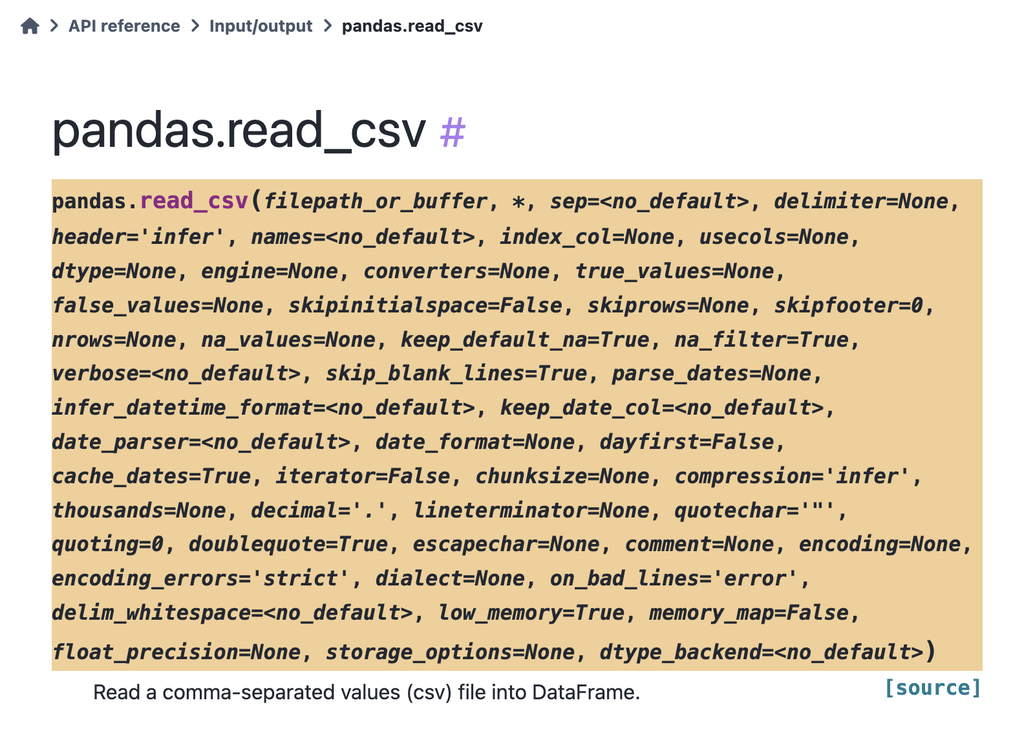

## Some definitions

- Parameter: A variable that is in a function definition. It acts as a stand-in for the value that will be passed when the function is called.
- Argument: When the function is called the argument is the actual value passed to it.

As you can see from the read_csv() example, one can program a function to have multiple parameters which can accept multiple arguments.

## Example: Multiple arguments

You’ve seen this about two lectures ago. What if we rewrite it to have multiple parameters? Orginally, name was only parameter. We could add the number of attempts and even a text to print out.

```python
def name_to_a1z26(name = None, attempts=3, suggestion="Too many invalid attempts. Please try again later"):
    while attempts > 0:
        if not name or name.strip() == "":
            name = input("Enter your name (or type 'exit' to quit): ")

        if name.lower() == "exit":
            print("Exiting the script")
            return

        elif name.isalpha():  # Check the name is in A-Z or a-z after removing spaces
            cipher_values = [ord(char) - 64 for char in name if char.isalpha()]
            print(f"Your name in A1Z26 cipher is: {cipher_values}")
            return

        attempts -= 1
        print(f"Invalid input. {attempts} attempts left.")

        if attempts == 0:
            print(suggestion)
            return

        name = None

if __name__ == "__main__":
    name_to_a1z26()
```

## (aside) if **name** == “**main**”:

- Recall - inclusion of `if __name__ == "__main__":` stops accidental execution if this script is imported into another program.
- Is useful when testing. Here it is imported into the REPL:

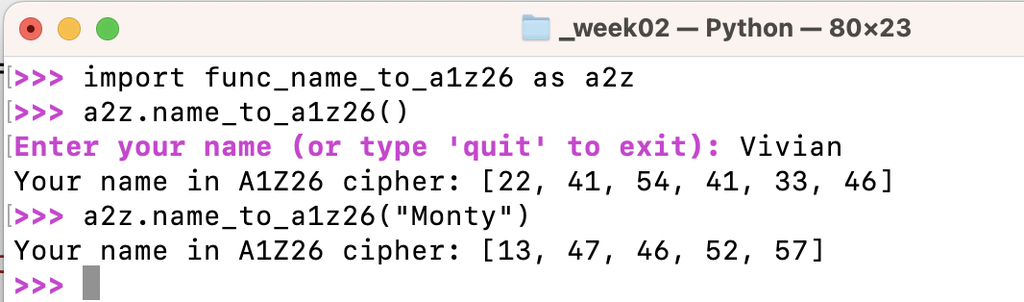

## What is **None** ?

- **None** is a keyword in Python
- **None** in Python is the absence of a value.
- **None** is not 0, False, or an empty string.
- **None** is a data type of its own, NoneType, and only None can be None.
- **None** is used to represent missing or default values, or as a return value for functions that do not return anything.

## Using None

- Setting a function parameter to **None** as a default value is a common practice.
- Use None when:
  - The parameter should not have a fixed default value.
  - You want to avoid mutable default arguments (they might modified and passed onward).
  - You want to declare a variable but don’t have an initial value for it yet
  - Use the **is** or **is not** operator to check if a variable is None

## Multiple parameter default values

- When we call functions with multiple parameters, we don’t necessarily have to provide an argument for every parameter, because some may have default values.
- Programming default values allow those parameters to behave as optional when calling the function

```python
def greet(name="Starshine", greeting="Good Morning"):
    print(f"{greeting}, {name}!")

greet()
greet("Vietnam")
greet("Chet", "Good Night")
```

```
Good Morning, Starshine!
Good Morning, Vietnam!
Good Night, Chet!
```

- The function is defined with two parameters (name and greeting).
- It can be called with 0, 1, or 2 arguments because of the default values.

## Positional Arguments

- The order of arguments matters when callling a function, recall the previous example.

```python
greet("Hello", "Clarice")
```

```
Clarice, Hello!
```

- When the order changes, the meaning changes (or it might not even run)

## Positional Argument Guidelines

- Positional Arguments must be provided in order.
- Unless Positional Arguments have default values, they cannot be skipped
- Positional arguments are good to use when their order makes sense.

## Keyword arguments

- You specify the argument name(s) when calling the function. The order is no longer critical.

```python
greet(greeting = "Hello", name = "Clarice")
```

```
Hello, Clarice!
```

- Specifying keywords makes the function call easier to understand.
- Use keyword arguments for clarity especially when you have many parameters

## When are arguments required?

- Required arguments are positional or keyword arguments that MUST be provided because they do not have defaults.
- Use required arguments for essential data that the function must have in order to work.
- Required arguments should be located at the beginning of the function. Pandas read_csv may have 50 parameters but it only requires one: the data file to be read.
- The `*` in the parameter list below marks the end of positional arguments and the start of keyword-only arguments

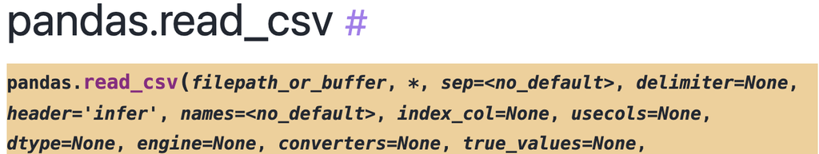

## `*args` and `**kwargs`

- `*args`
- Example
- `**kwargs`
- Example
- `*args` (Variable-length Positional Arguments) allows a function to accept any number of positional arguments
- data sequences like lists, tuples, sets must be unpacked first using *
- dictionaries need their values extracted too

Suppose you wanted to create a sum function that could use nearly any data structure and you don’t know in advance what a user will input:

```python
def arg_sum(*args):
    print("Received the following positional arguments:")
    for i, val in enumerate(args, 1):
        print(f"  Argument {i}: {val}")
    return sum(args)

# Try it out
result1 = arg_sum(5, 10, 15)
print("Result:", result1)

result2 = arg_sum(*list(range(1,5)))
print("Result:", result2)

result3 = arg_sum(*tuple(range(11,16)))
print("Result:", result3)

result4 = arg_sum(*set(range(6)))
print("Result:", result4)
```

```
Received the following positional arguments:
  Argument 1: 5
  Argument 2: 10
  Argument 3: 15
Result: 30
Received the following positional arguments:
  Argument 1: 1
  Argument 2: 2
  Argument 3: 3
  Argument 4: 4
Result: 10
Received the following positional arguments:
  Argument 1: 11
  Argument 2: 12
  Argument 3: 13
  Argument 4: 14
  Argument 5: 15
Result: 65
Received the following positional arguments:
  Argument 1: 0
  Argument 2: 1
  Argument 3: 2
  Argument 4: 3
  Argument 5: 4
  Argument 6: 5
Result: 15
```

`**kwargs` (Variable-length Keyword Arguments) allows our functions to accept any number of named arguments.

- These additional named arguments will be stored as a dictionary (dict).
- Keyword arguments provides flexibility when defining functions with optional parameters.
- Our function my_plot() uses `**kwargs`.
- It will accept any number of keyword arguments (such as color, linewidth) we did not need to specify them and matplotlib has many
- Passed to matplotlib.pyplot.plot() for processing

```
Forwarding the following kwargs to plt.plot():
  color = blue
  linewidth = 2
  linestyle = --
  marker = o
```

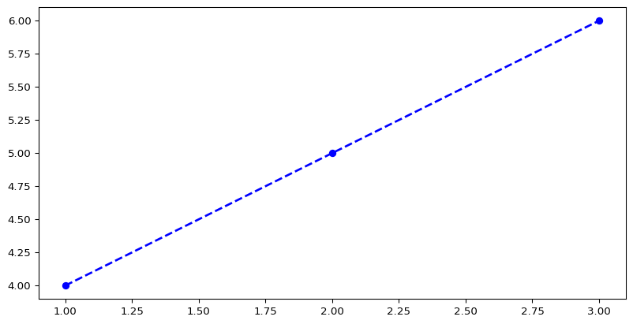

```python
import matplotlib.pyplot as plt

def my_plot(x, y, **kwargs):
    print("Forwarding the following kwargs to plt.plot():")
    for k, v in kwargs.items():
        print(f"  {k} = {v}")
    fig = plt.figure()
    fig.patch.set_facecolor('white')

    plt.plot(x, y, **kwargs)
    plt.show()

# Use it like a real matplotlib call
my_plot([1, 2, 3], [4, 5, 6], color='blue', linewidth=2, linestyle='--', marker='o')
```

## Takeaways

*args → collects positional arguments into a tuple

**kwargs → collects keyword arguments into a dictionary

Use *args when we don’t know how many positional arguments a user might pass

Use **kwargs when writing a function that can handle a variety of different inputs without having to specify them all in the function definition.

## Can you mix argument types?

Absolutely, we’ve been doing a little bit of that:

- Positional arguments come first.
- Next `*args` (variable-length positional arguments) if you are using them
- Keyword arguments (named parameters with default values, typically optional arguments) must come after *any* positional arguments
- lastly `**kwargs` (variable-length keyword arguments)

## Example: Mixing Parameters

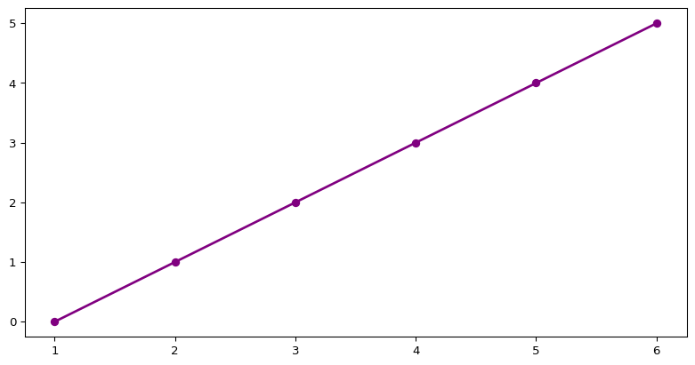

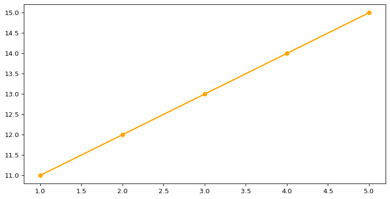

```python
import matplotlib.pyplot as plt


def flexible_function(*args, **kwargs):
    enumerated = list(enumerate(*args, 1))
    x = [i for i, x in enumerated]
    y = [x for i, x in enumerated]
    plt.plot(x, y, **kwargs)
    plt.show()

flexible_function(range(6), color='purple', linewidth=2, linestyle='-', marker='o')

flexible_function(tuple(range(11,16)), color='orange', linewidth=2, linestyle='-', marker='o')
```

## Example: Mixing Parameters Incorrectly

- The rules still apply, positional before keyword and parameters with no default before parameters with default.

```python
def my_function_bad(a = "hello", b, c, *args, **kwargs):
    pass

# fix
# def my_function_bad_fixed(a, b, c = "hello", *args, **kwargs):
#    pass
```

```
  Cell In[39], line 1
    def my_function_bad(a = "hello", b, c, *args, **kwargs):
                                     ^
SyntaxError: parameter without a default follows parameter with a default
```

## Takeways

- If the function you are writing has too many parameters, consider simplifying the function, perhaps by grouping parameters.
- If your function is doing too many things, recall “separation of concerns” and breaking the function into parts

Example: A function that calculates a Z score may call other functions that calculate a mean and standard deviation (since those functions have other uses) rather than calculating both of them inside the Z score function.

- Choose clarity over flexibility if it makes sense (recall PEP 20/Zen of Python)

Example: Pandas is writing to countless users and prioritizes flexibility in read_csv() because csv files can be messy. For homework, simpler is often better.

# more dictionaries

## The .items() method for dictionaries

- This method returns a *view object* containing key-value pairs as tuples
- A view object is a representation of a dictionary’s keys, values, or items (key-value pairs)
- View objects are dynamic and they automatically reflect changes made to their dictionary of origin

## Examples

- Dictionary
- Iterate
- Filter
- Transform
- Lookup
- Sort

```python
cities = {
    "New York": (40.7128, -74.0060),
    "Los Angeles": (34.0522, -118.2437),
    "Chicago": (41.8781, -87.6298),
    "Houston": (29.7604, -95.3698),
    "Phoenix": (33.4484, -112.0740),
    "Miami": (25.7617, -80.1918),
    "Seattle": (47.6062, -122.3321),
    "Denver": (39.7392, -104.9903),
    "Boston": (42.3601, -71.0589),
    "San Francisco": (37.7749, -122.4194)
}

# check
print(cities)
list(cities.items())
```

```
{'New York': (40.7128, -74.006), 'Los Angeles': (34.0522, -118.2437), 'Chicago': (41.8781, -87.6298), 'Houston': (29.7604, -95.3698), 'Phoenix': (33.4484, -112.074), 'Miami': (25.7617, -80.1918), 'Seattle': (47.6062, -122.3321), 'Denver': (39.7392, -104.9903), 'Boston': (42.3601, -71.0589), 'San Fra…
```

```
[('New York', (40.7128, -74.006)),
 ('Los Angeles', (34.0522, -118.2437)),
 ('Chicago', (41.8781, -87.6298)),
 ('Houston', (29.7604, -95.3698)),
 ('Phoenix', (33.4484, -112.074)),
 ('Miami', (25.7617, -80.1918)),
 ('Seattle', (47.6062, -122.3321)),
 ('Denver', (39.7392, -104.9903)),
 ('Boston', (42.3601, -71.0589)),
 ('San Francisco', (37.7749, -122.4194))]
```

```python
for city, coordinates in cities.items():
    print(f"{city}: Latitude {coordinates[0]}, Longitude {coordinates[1]}")
```

```
New York: Latitude 40.7128, Longitude -74.006
Los Angeles: Latitude 34.0522, Longitude -118.2437
Chicago: Latitude 41.8781, Longitude -87.6298
Houston: Latitude 29.7604, Longitude -95.3698
Phoenix: Latitude 33.4484, Longitude -112.074
Miami: Latitude 25.7617, Longitude -80.1918
Seattle: Latitude 47.6062, Longitude -122.3321
Denver: Latitude 39.7392, Longitude -104.9903
Boston: Latitude 42.3601, Longitude -71.0589
San Francisco: Latitude 37.7749, Longitude -122.4194
```

- Recall list comprehension https://peps.python.org/pep-0202/ part of Python’s syntax
- Dictionary comprehension (https://peps.python.org/pep-0274/) is similar.
- We can use dictionary comprehension to filter
- Syntax is {key: value for key, value in original_dict.items() if condition}

```python
filtered_dict = {cityname: coords for cityname, coords in cities.items() if coords[0] > 40}

for city, coordinates in filtered_dict.items():
    print(f"{city}: Latitude {coordinates[0]}, Longitude {coordinates[1]}")
```

```
New York: Latitude 40.7128, Longitude -74.006
Chicago: Latitude 41.8781, Longitude -87.6298
Seattle: Latitude 47.6062, Longitude -122.3321
Boston: Latitude 42.3601, Longitude -71.0589
```

- Use dictionary comprehension to transform values
- Here, we are just switching longitude and latitude but you could apply virtually any function

```python
cities_switched = {
    cityname: (coords[1],coords[0])
    for cityname, coords in cities.items()
}

for city, coordinates in cities_switched.items():
    print(f"{city}: Longitude {coordinates[0]}, Latitude {coordinates[1]}")
```

```
New York: Longitude -74.006, Latitude 40.7128
Los Angeles: Longitude -118.2437, Latitude 34.0522
Chicago: Longitude -87.6298, Latitude 41.8781
Houston: Longitude -95.3698, Latitude 29.7604
Phoenix: Longitude -112.074, Latitude 33.4484
Miami: Longitude -80.1918, Latitude 25.7617
Seattle: Longitude -122.3321, Latitude 47.6062
Denver: Longitude -104.9903, Latitude 39.7392
Boston: Longitude -71.0589, Latitude 42.3601
San Francisco: Longitude -122.4194, Latitude 37.7749
```

- Suppose our dictionary was enormous (e.g., every city in the world)
- Dictionaries can perform fast lookups using the get method

```python
coords = cities.get("Chicago")
if coords:
    print(f"Coordinates: {coords}")
else:
    print("City not found.")
```

```
Coordinates: (41.8781, -87.6298)
```

- Recall last lecture we examined the sorted() with lambda (an anonymous function)
- Lambda helps us to sort a dictionary, in this example, on the latitude in reverse order using a single line of code

```python
sorted_cities = dict(sorted(cities.items(), key=lambda item: item[1][0], reverse=True))

for city, coordinates in sorted_cities.items():
    print(f"{city}: Latitude {coordinates[0]}, Longitude {coordinates[1]}")
```

```
Seattle: Latitude 47.6062, Longitude -122.3321
Boston: Latitude 42.3601, Longitude -71.0589
Chicago: Latitude 41.8781, Longitude -87.6298
New York: Latitude 40.7128, Longitude -74.006
Denver: Latitude 39.7392, Longitude -104.9903
San Francisco: Latitude 37.7749, Longitude -122.4194
Los Angeles: Latitude 34.0522, Longitude -118.2437
Phoenix: Latitude 33.4484, Longitude -112.074
Houston: Latitude 29.7604, Longitude -95.3698
Miami: Latitude 25.7617, Longitude -80.1918
```

## Lambda

- lambda is a small anonymous (unnamed) function with a simple syntax
- syntax is *lambda arguments: expression*
- use it when you don’t want to write a full function when a simple one-line operation will do
- So in the previous slide on sorting dictionary values

```
lambda item: item[1][0]
```

instead of building another function and passing arguments to sorted()

```
def get_latitude(item):
    return item[1][0]

dict(sorted(cities.items(), key=get_latitude, reverse=True))
```

## Dictionary Comprehension Takeways

- Syntax {key: value for key, value in original_dict.items() if condition}
- Provides a concise (single line) way to create dictionaries
- Applies an expression to each item in an iterable (like a list, tuple or another dictionary) and can also filtering items based on a condition
- More efficient than a for loop

# Give Dictionaries a try

## Exercise

- Can you figure out what percentage of the 1000 parking spaces are VACANT right now?

```python
import urllib.request
import json

# URL to the data
url = "https://data.lacity.org/resource/e7h6-4a3e.json?$limit=1000"

# Make a request to the URL and read the response
with urllib.request.urlopen(url) as response:
    data_bytes = response.read()

# Decode the response and parse JSON
data_str = data_bytes.decode("utf-8")
data = json.loads(data_str)
print(data[:5]) # 'occupancystate': 'VACANT'
```

```
[{'spaceid': 'HO360', 'eventtime': '2025-05-20T01:12:21.000', 'occupancystate': 'OCCUPIED'}, {'spaceid': 'SV506A', 'eventtime': '2025-05-20T01:12:11.000', 'occupancystate': 'OCCUPIED'}, {'spaceid': 'SV455', 'eventtime': '2025-05-20T01:12:04.000', 'occupancystate': 'OCCUPIED'}, {'spaceid': 'SV507', '…
```

## Zip

- Zip will iterate over several iterables in parallel, producing tuples with an item from each one.
- zip() is lazy, no processing it is iterated on, e.g. by a for loop or by making a list
- if the iterables passed to zip() have different lengths, default behavior is zip() stops when the shortest iterable is exhausted
- add the option strict = True to throw an error instead

```python
for item in zip(range(4), ['Alpha', 'Beta', 'Gamma', 'Delta'], ['King', 'Queen', 'Jack', 'Ten']):
    print(item)
```

```
(0, 'Alpha', 'King')
(1, 'Beta', 'Queen')
(2, 'Gamma', 'Jack')
(3, 'Delta', 'Ten')
```

## Applications of zip()

```python
matrix = [
    [1, 2, 3, 4],
    [5, 6, 7, 8]
]
transpose_matrix = [list(row) for row in zip(*matrix)]
transpose_matrix
```

```
[[1, 5], [2, 6], [3, 7], [4, 8]]
```

```python
keys = ['name', 'city', 'occupation']
values = ['Jesse', 'Austin', 'Programmer']

person = dict(zip(keys, values))
person
```

```
{'name': 'Jesse', 'city': 'Austin', 'occupation': 'Programmer'}
```

## (later) but in truth…

Just Use NumPy:

```python
import numpy as np

matrix = [
    [1, 2, 3, 4],
    [5, 6, 7, 8]
]

np_matrix = np.array(matrix)
np_transposed = np_matrix.T
print(np_transposed)
```

```
[[1 5]
 [2 6]
 [3 7]
 [4 8]]
```

## Enumerate

- enumerate(iterable, start=0) and returns an enumerate object
- use it when you need index + item
- use it whe you want positional information of a single iterable

## Enumerate applications example

```python
words = ("low", "medium", "high")
print(f"We want to number {words}")
for index, word in enumerate(words):
    print(index, word)
print("-" * 40)

file_path = "gettysburg.txt"
with open(file_path, "r", encoding="utf-8") as file:
    text = file.read()
    getty_words = text.split()

target = 'nation'
print(f"We want to find {target}")

for i, item in enumerate(getty_words):
    if item == target:
        print(f"Target Found at index {i}")
        break

print(f"We checked and getty_words[{i}] is '{getty_words[i]}' ")
```

```
We want to number ('low', 'medium', 'high')
0 low
1 medium
2 high
----------------------------------------
We want to find nation
Target Found at index 45
We checked and getty_words[45] is 'nation'
```

## Recall LEGB

- What is available to us?

```python
locals()
```

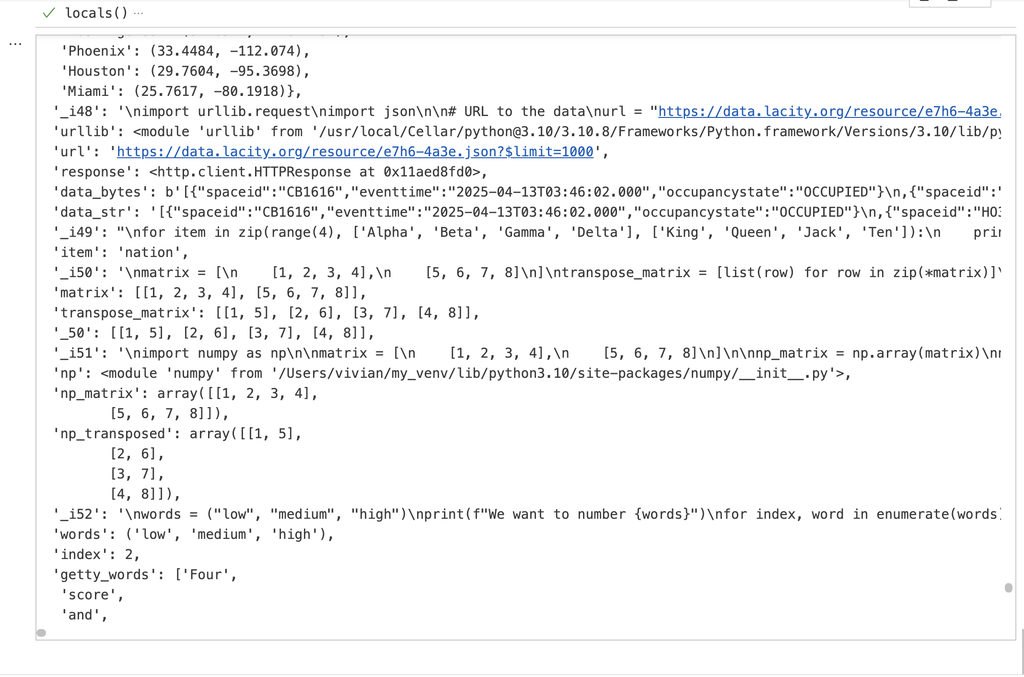

## Reading data

- If you are trying to manage resources on your own, do use a **with** when reading data from any source:

```python
import urllib.request
import json

# URL to the data
url = "https://data.lacity.org/resource/e7h6-4a3e.json?$limit=1000"

# Make a request to the URL and read the response
with urllib.request.urlopen(url) as response:
    data_bytes = response.read()

print(f"Is response closed? {response.closed}")

# local drive data
with open("case.json", "r") as file:
    data_coroner = json.load(file)

print(f"Is file closed? {file.closed}")
```

```
Is response closed? True
Is file closed? True
```

## Writing data to json

- The same is true with writing data

```python
import urllib.request
import json

# Decode and load JSON data
data_str = data_bytes.decode("utf-8")
data_parking = json.loads(data_str)

# Save the data to a local JSON file
with open("data_parking.json", "w", encoding="utf-8") as f:
    json.dump(data_parking, f, indent=2, ensure_ascii=False)

print("Data saved to data_parking.json")
```

```
Data saved to data_parking.json
```

## Writing json data to csv

```python
import json
import csv

# local drive data
with open("case.json", "r") as file:
    data = json.load(file)

# Decode and load JSON data
# data_coroner = json.loads(data)

if data:
    fieldnames =  data['cases'][0].keys()

    with open("data_coroner.csv", "w", newline="", encoding="utf-8") as f:
        writer = csv.DictWriter(f, fieldnames=fieldnames)
        writer.writeheader()
        writer.writerows(data['cases'])

    print("Data saved to data_coroner.csv")
else:
    print("No data to write.")
```

```
Data saved to data_coroner.csv
```

## Suggested exercise

- If you get a chance, try the optional page on Sets and Dictionaries
- Try writing the resulting data object to csv